# SpaceANOVA

Souvik Seal

This is an R package implementing the proposed method from the paper, “SpaceANOVA: Spatial co-occurrence analysis of cell types in multiplex imaging data using point process and functional ANOVA”. It can be used to study differential spatial co-occurrence of pairs of cell types across multiple groups, such as case/control, in multiplex imaging datasets.

## Loading the package

We install and load the developmental version of SpaceANOVA from GitHub.

```r
suppressWarnings(devtools::install_github('sealx017/SpaceANOVA'))
require(SpaceANOVA)

require(spatstat)
require(tidyr)
require(dplyr)
require(fda.usc)
require(ggplot2)
require(cowplot)
require(gridExtra)
```

## Loading the example dataset

Next, we import the type 1 diabetis melitus (T1DM) IMC dataset [1]. The input data should have a simple form: a) rows should correspond to individual cells, and b) six columns should correspond to the group, subject, and image indices of the cell, along with it’s x,y co-ordinates and cell type. In the original dataset, there were three groups of subjects: “Non-diabetic”, “Onset”, and “Long-duration” (4 in each group). We truncated the dataset to have only the first two groups for simplicity. It should be highlighted that our method can handle any number of groups (more than 2).

```r
data("IMC_T1DM")
knitr::kable(head(IMC_T1DM), format="markdown")
```

| Group | ID | imageID | x | y | cellType |
| --- | --- | --- | --- | --- | --- |
| Onset | 6362 | A01 | 53 | 0 | Others |
| Onset | 6362 | A01 | 128 | 0 | Others |
| Onset | 6362 | A01 | 135 | 0 | Others |
| Onset | 6362 | A01 | 450 | 0 | Others |
| Onset | 6362 | A01 | 458 | 0 | Others |
| Onset | 6362 | A01 | 551 | 0 | Others |

```r
IMC_T1DM %>% group_by(Group, ID) %>% reframe(n = n()) # check group and subject IDs, and respective cell counts (spread across multiple images)
# # A tibble: 8 × 3
#   Group        ID         n
#   <fct>        <fct>  <int>
# 1 Non-diabetic 6126  158693
# 2 Non-diabetic 6134  181609
# 3 Non-diabetic 6386  127350
# 4 Non-diabetic 6278  185399
# 5 Onset        6362  202272
# 6 Onset        6414  166052
# 7 Onset        6228  142106
# 8 Onset        6380  129456
```

## Compute the summary functions and perform association analysis

This function can be used to perform the entire analysis at one go, starting from summary function estimation to the univariate and multivariate FANOVA-based association analyses. The function takes several input parameters out of which the most important ones are displayed below. “fixed_r” corresponds to the grid values of radius r. “Summary_function” corresponds to which summary function to be used: g, K, or L. “Hard_ths” corresponds to the lowest number of a particular cell type, say A, that an image can have (the image will be dropped if not for any pair of cell types involving A). “perm” is used to employ the permutation envelope-based adjustment to the summary functions in presence of holes in images and “nPerm” denotes the number of permutations to be used. “cores” is the number of cores to be used, if more than 1, mclapply (parallel package) is called to construct the permutation envelope.

```r
Final_result = All_in_one(data = IMC_T1DM, fixed_r = seq(0, 100, by = 5), Summary_function = "g", Hard_ths = 10, perm = TRUE, nPerm = 20, cores = 8)
# [1] 2
# [1] 3
# [1] 4
# [1] 5
# [1] 6
# [1] 7
# [1] 8
# [1] 9
```

## Extracting p-values

Extract the p-values of the univariate and multivariate tests: SpaceANOVA Univ. and SpaceANOVA Mult. and print.

```r
p_res = p_extract(Final_result)
Univ_p = p_res[[1]]
Mult_p = p_res[[2]]
print(Univ_p)
#              Others           Tc           Th        alpha        delta
# Others 7.004682e-01 1.558692e-01 6.342162e-01 6.854679e-15 6.947131e-05
# Tc     1.582080e-01 1.017808e-05 6.516621e-01 8.464232e-10 2.985644e-01
# Th     6.525986e-01 6.628249e-01 1.733123e-01 3.719233e-03 1.794968e-07
# alpha  5.169020e-15 5.426634e-10 6.456395e-03 2.254494e-12 1.713770e-04
# delta  8.200688e-05 2.580213e-01 4.120269e-08 1.529797e-04 5.363870e-05
# beta   8.193180e-02 2.235109e-01 6.082712e-03 5.057385e-02 1.934543e-04
#                beta
# Others 7.489300e-02
# Tc     2.228907e-01
# Th     3.127875e-03
# alpha  2.842268e-02
# delta  6.041251e-06
# beta   2.779546e-01
```

## Heatmap of -log10 of p-values

Display the -log10 of the p-values using heatmap.

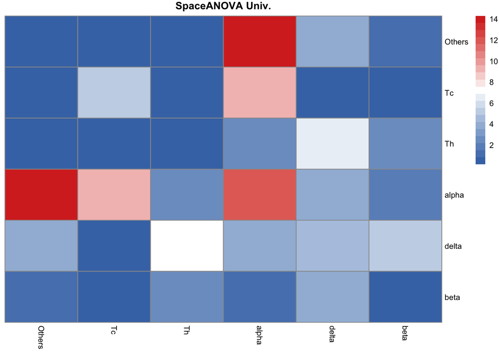

```r
Plot.heatmap(Univ_p, main = "SpaceANOVA Univ.")
```

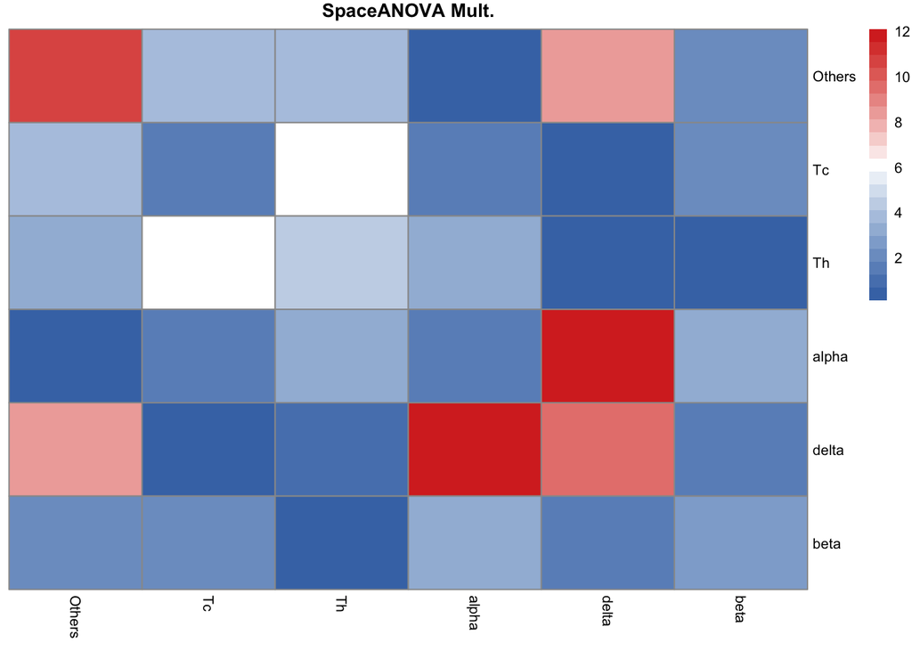

```r
Plot.heatmap(Mult_p, main = "SpaceANOVA Mult.")
```

## Visualizing summary functions

### Pair: (alpha, alpha)

We notice that the spatial co-occurrence of alpha cells is positive in both the groups but decreases in the “Onset” group.

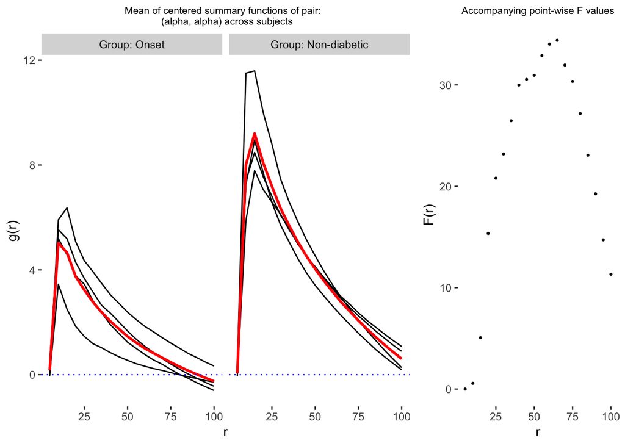

```
#
# [[2]]
```

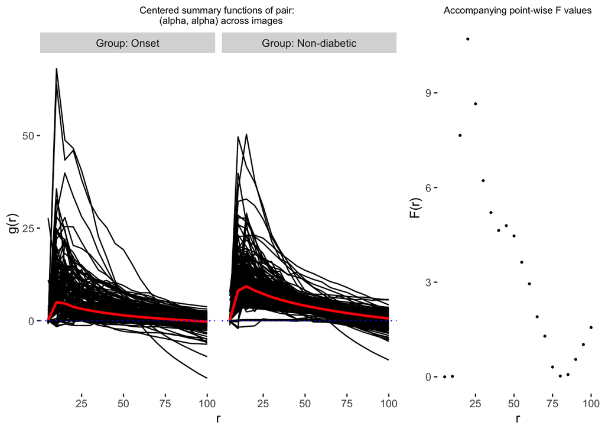

```r
Pointwise_Fvals = Final_result[[1]][[2]]
Functional_results = Final_result[[2]]

# Pair: (alpha, alpha)
Plot.functions(Functional_results, pair = c("alpha", "alpha"), Fvals = Pointwise_Fvals)
# [[1]]
```

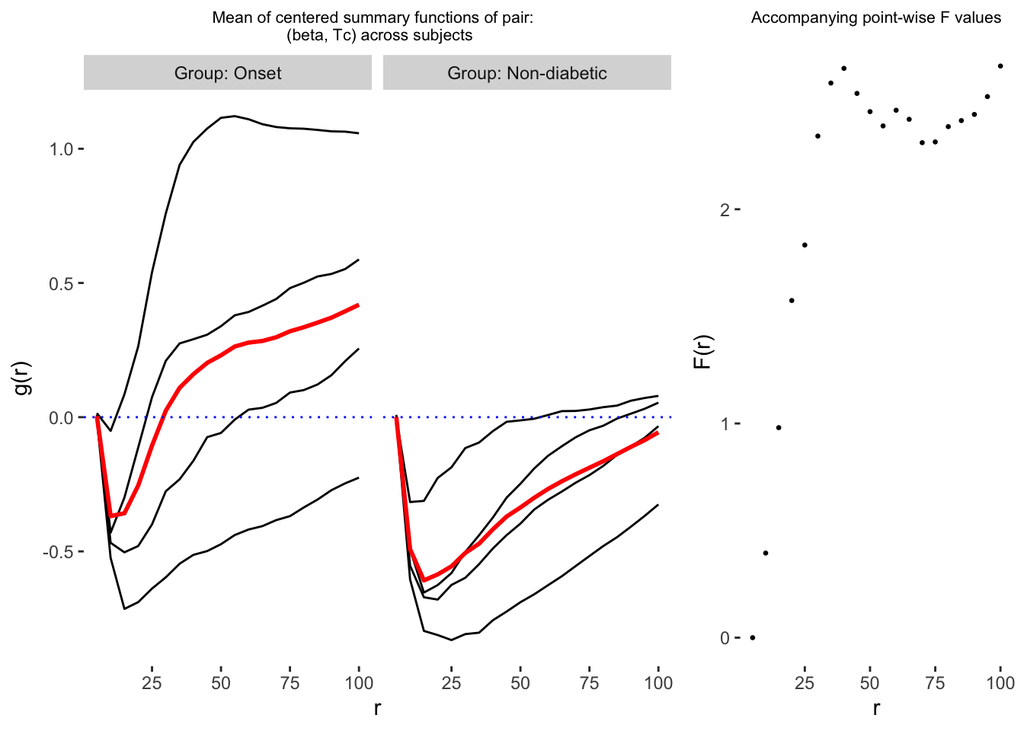

```
#
# [[2]]
```

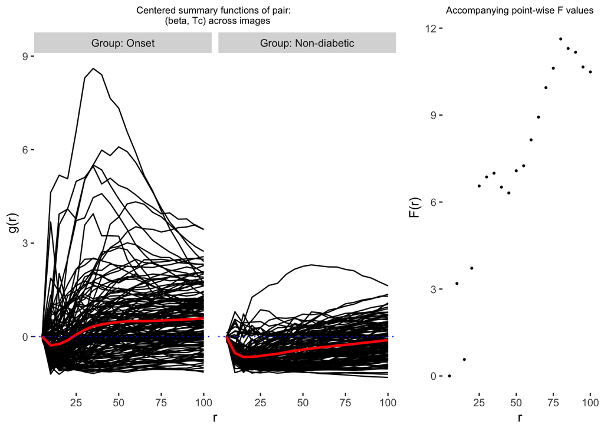

```r
# Pair: (beta, Tc)
Plot.functions(Functional_results, pair = c("beta", "Tc"), Fvals = Pointwise_Fvals)
# [[1]]
```